# Verificando qualidade dos dados

Juan Carlos Carbajal Ipenza

### Livrarias

```r
library(plyr)
library(readr)
library(stringr)
```

## Poucos dados em Ceará e Pernambuco

Verificar por qual razão a gente tem poucos dados nesses estados.

### Pre-processamento

Para importar um csv.

```r
importCSV <- function(file) {
   print(paste("Importing ", file, " ...", sep = ""))
   csv = read.csv(file, sep = ";", na.strings = "", stringsAsFactors = T,colClasses = c(
      "character", "character", "character", "NULL", # id, dataNotificacao, dataInicioSintomas, dataNascimento
      "character", "factor", "NULL", "character", # sintomas, profissionalSaude, cbo, condicoes
      "factor", "character", "factor", "factor", # estadoTeste, dataTeste, tipoTeste, resultadoTeste
      "NULL", "factor", "NULL", "factor", # paisOrigem, sexo, estado, estadoIBGE
      "NULL", "factor", "NULL", "NULL", # municipio, municipioIBGE, origem, estadoNotificacao
      "factor", "NULL", "factor", "NULL", # estadoNotificacaoIBGE, municipioNotificacao, municipioNotificacaoIBGE, excluido
      "NULL", "character", "character", "factor", # validado, idade, dataEncerramento, evolucaoCaso
      "factor")) # classificacaoFinal
   return(csv)
}
```

Processando todos os cSV’s.

```r
myfiles = list.files(path="dados", pattern="*.csv", full.names=TRUE)
myfiles
```

```
 [1] "dados/dados-ac.csv"   "dados/dados-al.csv"   "dados/dados-am.csv"   "dados/dados-ap.csv"   "dados/dados-ba-1.csv"
 [6] "dados/dados-ba-2.csv" "dados/dados-ce.csv"   "dados/dados-df.csv"   "dados/dados-es.csv"   "dados/dados-go-1.csv"
[11] "dados/dados-go-2.csv" "dados/dados-ma.csv"   "dados/dados-mg-1.csv" "dados/dados-mg-2.csv" "dados/dados-mg-3.csv"
[16] "dados/dados-ms.csv"   "dados/dados-mt.csv"   "dados/dados-pa.csv"   "dados/dados-pb.csv"   "dados/dados-pe.csv"
[21] "dados/dados-pi.csv"   "dados/dados-pr-1.csv" "dados/dados-pr-2.csv" "dados/dados-rj-1.csv" "dados/dados-rj-2.csv"
[26] "dados/dados-rn.csv"   "dados/dados-ro.csv"   "dados/dados-rr.csv"   "dados/dados-rs-1.csv" "dados/dados-rs-2.csv"
[31] "dados/dados-rs-3.csv" "dados/dados-sc-1.csv" "dados/dados-sc-2.csv" "dados/dados-se.csv"   "dados/dados-sp-1.csv"
[36] "dados/dados-sp-2.csv" "dados/dados-sp-3.csv" "dados/dados-sp-4.csv" "dados/dados-sp-5.csv" "dados/dados-sp-6.csv"
[41] "dados/dados-sp-7.csv" "dados/dados-to.csv"
```

```r
dados = ldply(myfiles, importCSV)
```

```
[1] "Importing dados/dados-ac.csv ..."
[1] "Importing dados/dados-al.csv ..."
[1] "Importing dados/dados-am.csv ..."
[1] "Importing dados/dados-ap.csv ..."
[1] "Importing dados/dados-ba-1.csv ..."
[1] "Importing dados/dados-ba-2.csv ..."
[1] "Importing dados/dados-ce.csv ..."
[1] "Importing dados/dados-df.csv ..."
[1] "Importing dados/dados-es.csv ..."
[1] "Importing dados/dados-go-1.csv ..."
[1] "Importing dados/dados-go-2.csv ..."
[1] "Importing dados/dados-ma.csv ..."
[1] "Importing dados/dados-mg-1.csv ..."
[1] "Importing dados/dados-mg-2.csv ..."
[1] "Importing dados/dados-mg-3.csv ..."
```

[output cut: 27 more lines]

```r
colnames(dados)
```

```
 [1] "ÿid"                      "dataNotificacao"          "dataInicioSintomas"       "sintomas"
 [5] "profissionalSaude"        "condicoes"                "estadoTeste"              "dataTeste"
 [9] "tipoTeste"                "resultadoTeste"           "sexo"                     "estadoIBGE"
[13] "municipioIBGE"            "estadoNotificacaoIBGE"    "municipioNotificacaoIBGE" "idade"
[17] "dataEncerramento"         "evolucaoCaso"             "classificacaoFinal"       "estadoNotificacao"
[21] "municipioNotificacao"     "validado"
```

```r
dim(dados)
```

```
[1] 31952603       22
```

```r
head(dados)
```

|  | ÿid | dataNotificacao | dataInicioSintomas | sintomas | profissionalSaude | condicoes | estadoTeste | dataTeste | tipoTeste | resultadoTeste | sexo | estadoIBGE | municipioIBGE | estadoNotificacaoIBGE | municipioNotificacaoIBGE | idade | dataEncerramento | evolucaoCaso | classificacaoFinal | estadoNotificacao | municipioNotificacao | validado |
| --- | --- | --- | --- | --- | --- | --- | --- | --- | --- | --- | --- | --- | --- | --- | --- | --- | --- | --- | --- | --- | --- | --- |
| 1 | rEMi4NbsW6 | 2020-04-20T03:00:00.000Z | 2020-04-20T03:00:00.000Z | Outros | Sim | null | Concluído | 2020-04-20T05:00:00.000Z | RT-PCR | Negativo | Feminino | 12 | 1200401 | 12 | 1200401 | 35 | NA | NA | Descartado | NA | NA | NA |
| 2 | jmnK1lW15C | 2020-04-21T05:00:00.000Z | 2020-04-17T05:00:00.000Z | Dor de Garganta, Febre, Tosse | Não | null | Concluído | 2020-04-21T05:00:00.000Z | RT-PCR | Positivo | Feminino | 12 | 1200401 | 12 | 1200401 | 41 | 2020-04-25T05:00:00.000Z | Em tratamento domiciliar | Confirmado Laboratorial | NA | NA | NA |
| 3 | iBgvfjNsVc | 2020-04-21T03:00:00.000Z | 2020-04-16T03:00:00.000Z | Tosse, Febre | Não | Imunossupressão | Concluído | 2020-04-20T05:00:00.000Z | RT-PCR | Negativo | Masculino | 12 | 1200401 | 12 | 1200401 | 7 | NA | NA | Descartado | NA | NA | NA |
| 4 | 24tEfrmYGL | 2020-04-09T16:05:28.450Z | 2020-04-07T03:00:00.000Z | Dispneia, Febre, Tosse | Não | Doenças cardíacas crônicas, Imunossupressão | Concluído | 2020-04-09T05:00:00.000Z | RT-PCR | Negativo | Feminino | 12 | 1200401 | 12 | 1200401 | 47 | NA | NA | Descartado | NA | NA | NA |
| 5 | IAJbjpSIWG | 2020-04-21T03:00:00.000Z | 2020-04-20T03:00:00.000Z | Tosse, Febre | Não | Doenças cardíacas crônicas, Imunossupressão | Concluído | 2020-04-20T05:00:00.000Z | RT-PCR | Negativo | Feminino | 12 | 1200401 | 12 | 1200401 | 47 | 2020-04-25T05:00:00.000Z | Cancelado | Descartado | NA | NA | NA |
| 6 | cLuEg94cSH | 2020-04-15T17:50:12.632Z | 2020-04-13T05:00:00.000Z | Outros | Não | null | Concluído | 2020-04-15T05:00:00.000Z | RT-PCR | Negativo | Masculino | 12 | 1200401 | 12 | 1200401 | 70 | NA | NA | Descartado | NA | NA | NA |

Corrigindo colunas.

```r
colnames(dados)[1] = "id"
dados$estadoNotificacao = NULL
dados$municipioNotificacao = NULL
dados$validado = NULL

colnames(dados)
```

```
 [1] "id"                       "dataNotificacao"          "dataInicioSintomas"       "sintomas"
 [5] "profissionalSaude"        "condicoes"                "estadoTeste"              "dataTeste"
 [9] "tipoTeste"                "resultadoTeste"           "sexo"                     "estadoIBGE"
[13] "municipioIBGE"            "estadoNotificacaoIBGE"    "municipioNotificacaoIBGE" "idade"
[17] "dataEncerramento"         "evolucaoCaso"             "classificacaoFinal"
```

### Verificando dados dos estados com poucos dados

Os UF’s para os estados de Ceará e Pernambuco são 23 e 26 respetivamente. Pelo que vemos nos dados tem 12 246 e 23 898 dados. Na visualização que a gente fez temos a mesma quantidade de dados. Ou seja, a gente não apagou dados no tratamento.

```r
summary(dados$estadoNotificacaoIBGE)
```

```
       11        12        13        14        15        16        17        21        22        23        24        25        26
   472213    173946    724898    203449    760020    148328    278688    655722    506581     12246    732120    818783     23898
       27        28        29        31        32        33        35        41        42        43        50        51        52
   433261    308547   1966547   2852529    463553   1973348   6300893   1048990   2019828   2990103    711770    445043   1257758
       53 undefined      NA's
   463246     26272   3180023
```

Olhando o gráfico dos estados com menos de 500 000 atendimentos podemos notar que só os estados analisados tem menos de 100 000 atendimentos. Os seguintes seriam Amapá e Acre com 148 328 e 173 946 respetivamente.

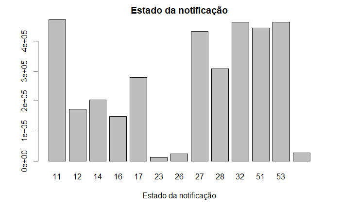

```r
counts = table(dados$estadoNotificacaoIBGE)
barplot(counts[counts < 500000], main = "Estado da notificação", xlab = "Estado da notificação")
```

Verificando os dados com os estados de residência e não com os estados de notificação vemos que temos melhores dados nesses estados analisados.

```r
summary(dados$estadoIBGE)
```

```
       12 undefined        27        13        16        29        11        14        15        17        21
   179812     36578    447195    780086    157708   2032211    474429    209640    777010    280937    688944
       22        23        24        25        26        28        31        32        33        35        41
   518191    986974    750123    840497    788287    312864   3149472    498641   1992852   7939121    125978
       42        43        50        51        52        53
  2001984   3010034    710660    459994   1322796    479585
```

Olhando o gráfico dos estados com menos de 500 000 atendimentos, a gente nota que os estados de Paraná, Amapá e Acre têm 125 978, 157 708 e 179 812 atendimentos. É interesante ver que os dois últimos estados têm quase a mesma quantidade que tem nos valores de notificação. Porém o estado de Paraná tem um decremento de quase 900 mil atendimentos.

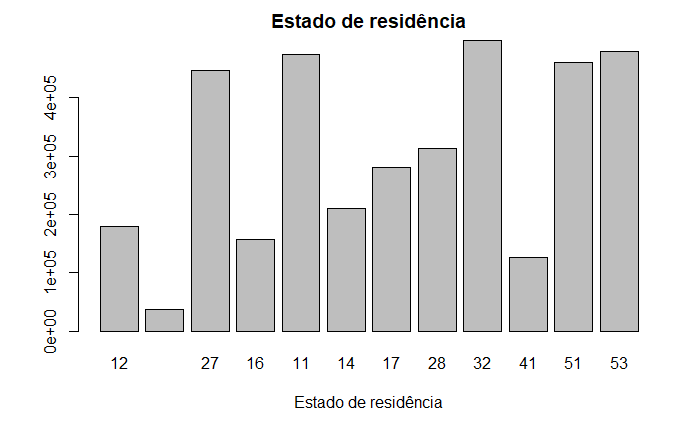

```r
counts = table(dados$estadoIBGE)
barplot(counts[counts < 500000], main = "Estado de residência", xlab = "Estado de residência")
```

### Considerações finais

Os dados de estado de notificação nos estados estudiados tem poucos dados. Além disso o estado de notificação tem como 3,2 milhões de dados indefinidos (NA’s e undefined nos dados originais) comparado ao estado de residência que só tem 36578 indefinidos. Olhando a ficha de registro, o instrutivo de preenchimento da ficha e o dicionário de dados podemos verificar que o estado de notificação é preenchido pelo sistema e o estado de residência é um preenchimento manual obrigatório. Como conclusão é recomendável usar o campo estado de residência invés do campo de estado de notificação por ter dados mais limpos e que ajudariam ao análise.

## Poucos dados dos óbitos

Listamos a evolução do caso que é a dimensão onde estão os óbito. Vemos que temos 53 183 óbitos que são os dados mostrados na visualização. Também vemos que temos 18,6 milhões de NA’s que é justificado porque o campo não é obrigatório segundo o dicionário de dados e o instrutivo de preenchimento da ficha. Então, em conclusão temos poucos óbitos porque não são preenchidos obrigatóriamente na ficha.

```r
summary(dados$evolucaoCaso)
```

```
               Cancelado                     Cura Em tratamento domiciliar                 Ignorado
                 1761379                  8998365                   849268                  1647621
               Internado         Internado em UTI                    Óbito                     NA's
                   15802                     3198                    53183                 18623787
```

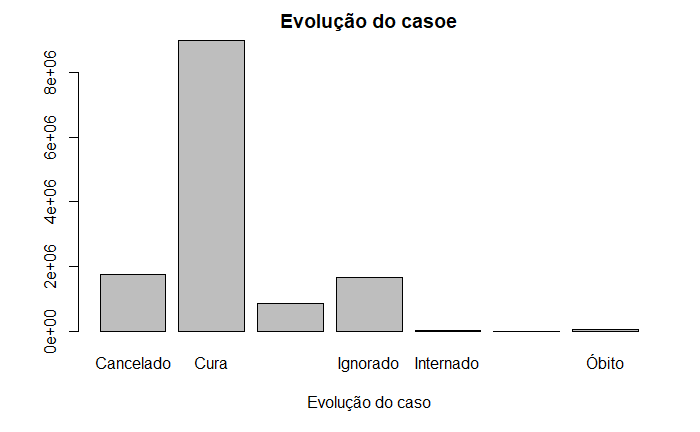

```r
counts = table(dados$evolucaoCaso)
barplot(counts, main = "Evolução do casoe", xlab = "Evolução do caso")
```

Adicionando ao análise, os estados de Sergipe, Paraná e Mato Grosso do Sul tem menos de 200 óbitos registrados.

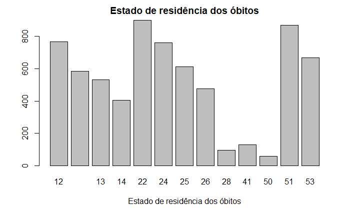